# Markup Assignment 2

Shannon Dickson

October 28 2022

# Comparing Bootstrap Standard Errors to Regular OLS Standard Errors

## Preparation

Before doing anything, we must set a seed to make the results reproducible.

```r
set.seed(4231)
```

Now we can load all of the necessary packages.

```r
library(dplyr)
library(magrittr)
library(purrr)
library(modelr)
library(ggplot2)
library(kableExtra)
```

We will work with the build-in R data set, `iris`. The first few rows of this data set are shown below.

**Table 1: Overview of the iris dataset**

```r
head(iris) %>%
  kable("html") %>%
    kable_styling(bootstrap_options = c("striped", "hover", "condensed"), full_width = F)
```

| Sepal.Length | Sepal.Width | Petal.Length | Petal.Width | Species |
| --- | --- | --- | --- | --- |
| 5.1 | 3.5 | 1.4 | 0.2 | setosa |
| 4.9 | 3.0 | 1.4 | 0.2 | setosa |
| 4.7 | 3.2 | 1.3 | 0.2 | setosa |
| 4.6 | 3.1 | 1.5 | 0.2 | setosa |
| 5.0 | 3.6 | 1.4 | 0.2 | setosa |
| 5.4 | 3.9 | 1.7 | 0.4 | setosa |

## OLS Regression

Using `lm` we can fit an OLS regression model to the `iris` data set, predicting `Sepal.Length`.

```r
m1 <- lm(Sepal.Length ~ Petal.Length + Petal.Width + Sepal.Width, data = iris)
summary(m1)
```

```
##
## Call:
## lm(formula = Sepal.Length ~ Petal.Length + Petal.Width + Sepal.Width,
##     data = iris)
##
## Residuals:
##      Min       1Q   Median       3Q      Max
## -0.82816 -0.21989  0.01875  0.19709  0.84570
##
## Coefficients:
##              Estimate Std. Error t value Pr(>|t|)
## (Intercept)   1.85600    0.25078   7.401 9.85e-12 ***
## Petal.Length  0.70913    0.05672  12.502  < 2e-16 ***
## Petal.Width  -0.55648    0.12755  -4.363 2.41e-05 ***
## Sepal.Width   0.65084    0.06665   9.765  < 2e-16 ***
## ---
## Signif. codes:  0 '***' 0.001 '**' 0.01 '*' 0.05 '.' 0.1 ' ' 1
##
## Residual standard error: 0.3145 on 146 degrees of freedom
## Multiple R-squared:  0.8586, Adjusted R-squared:  0.8557
## F-statistic: 295.5 on 3 and 146 DF,  p-value: < 2.2e-16
```

## Bootstrap Regression

The `bootstrap` function from `modelr` is a simple way of performing a bootstrap using `tidy` principles. I chose to resample the `iris` data 10,000 since the original data set is quite small. `bootstrap()` creates a tibble of 10,000 resampled data sets (with replacement).

```r
boot_iris <- iris %>%
  bootstrap(10000)
```

Next I run the regression model over all of the 10,000 data sets and use `broom()` function to nicely format the models in a tibble.

```r
boot_iris %>%
    mutate(lm = map(strap, ~lm(Sepal.Length ~ Petal.Length + Petal.Width + Sepal.Width, data = .)),
           tidy = map(lm, broom::tidy)) -> boot_iris
```

Now I can summarise the results from the 10,000 regressions. The code below pulls all of the `lm` objects and tidied the output by binding them as rows.

```r
boot_iris %>%
  pull(tidy) %>%
  map2_df(., seq(1, 10000), ~mutate(.x, resample = .y)) -> tidy_boot_iris

head(tidy_boot_iris)
```

```
## # A tibble: 6 × 6
##   term         estimate std.error statistic  p.value resample
##   <chr>           <dbl>     <dbl>     <dbl>    <dbl>    <int>
## 1 (Intercept)     2.24     0.227       9.83 7.92e-18        1
## 2 Petal.Length    0.659    0.0509     12.9  5.53e-26        1
## 3 Petal.Width    -0.422    0.114      -3.70 3.09e- 4        1
## 4 Sepal.Width     0.535    0.0619      8.64 9.13e-15        1
## 5 (Intercept)     1.55     0.230       6.76 3.13e-10        2
## 6 Petal.Length    0.744    0.0575     12.9  5.24e-26        2
```

```r
tidy_boot_iris %>%
  # the term is the different species of flower
  group_by(term) %>%
  # summarise the bootstrapped standard error (standard deviation of the coefficients of the model parameters)
  summarise(boot_se = sd(estimate)) -> boot_se_m1

boot_se_m1
```

```
## # A tibble: 4 × 2
##   term         boot_se
##   <chr>          <dbl>
## 1 (Intercept)   0.231
## 2 Petal.Length  0.0627
## 3 Petal.Width   0.145
## 4 Sepal.Width   0.0617
```

## Comparison of OLS and Bootstrapped Standard Errors

**Table 2: OLS and bootstrapped standard errors for each of the model parameters**

```r
broom::tidy(m1) %>% select(std.error) %>%
  cbind(boot_se_m1) %>%
  select(-term) %>%
  kable("html", col.names = c("OLS Standard Errors", "Bootstrapped Standard Errors")) %>%
  kable_styling(bootstrap_options = c("striped", "hover", "condensed"), full_width = F)
```

| OLS Standard Errors | Bootstrapped Standard Errors |
| --- | --- |
| 0.2507771 | 0.2309143 |
| 0.0567193 | 0.0626710 |
| 0.1275479 | 0.1446185 |
| 0.0666474 | 0.0616734 |

**Figure 1. Visualisation of the OLS and bootstrapped standard errors for each of the model parameters**

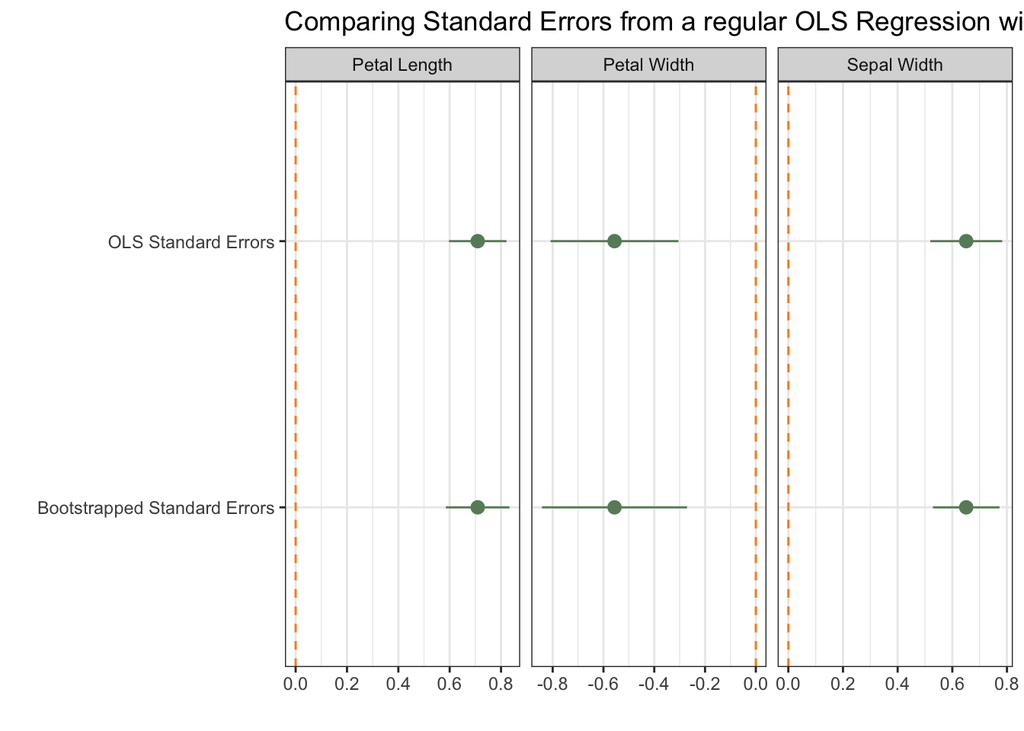

```r
broom::tidy(m1) %>%
  mutate(category = "OLS Standard Errors") %>%
  bind_rows(., broom::tidy(m1) %>% select(-std.error) %>% left_join(., boot_se_m1 %>% rename(std.error = boot_se))) %>%
  mutate(category = ifelse(is.na(category), "Bootstrapped Standard Errors", category),
         tstat = estimate/std.error,
         pval = 1.975*pt(-abs(tstat),df=45),
         lwr = estimate - 1.975*std.error,
         upr = estimate + 1.975*std.error) %>%
  filter(term != "(Intercept)") %>%
  mutate(term = forcats::fct_recode(term,
                                    "Petal Length" = "Petal.Length",
                                    "Petal Width" = "Petal.Width",
                                    "Sepal Width" = "Sepal.Width")) %>%
  ggplot(.,aes(category, estimate, ymin = lwr, ymax = upr)) +
  geom_pointrange(position = position_dodge(width = 1), colour = "darkseagreen4") +
  geom_hline(yintercept = 0, linetype = "dashed", colour = "darkorange") +
  labs(x = " ", y = " ",
       title = "Comparing Standard Errors from a regular OLS Regression with Bootsrapepd Standard Errors") +
  theme_bw() +
  facet_wrap(~term, scales = "free_x") +
  coord_flip()
```